# matching_external_cohort

Gabriel Innocenti

2026-02-27

## Define functions

```r
# Create database
generate_db <- function(metadata,
                 group_var = NULL,
                 project_var = NULL,
                 sex_var = NULL,
                 age_interval = NULL) {

  # Remove NAs in sex and age
  metadata_vecmatch <- metadata %>%
    filter(!is.na(sex), !is.na(age))

  # Conditional filters
  if (!is.null(group_var)) {
    metadata_vecmatch <- metadata_vecmatch %>%
      filter(group_var == group_test)
  }

  if (!is.null(sex_var)) {
    metadata_vecmatch <- metadata_vecmatch %>%
      filter(sex_var == sex_var)
  }

  if (!is.null(project_var)) {
    metadata_vecmatch <- metadata_vecmatch %>%
      filter(project_var == project)
  }

  if (!is.null(age_interval) && length(age_interval) == 2) {
    metadata_vecmatch <- metadata_vecmatch %>%
      filter(age >= age_interval[1], age <= age_interval[2])
  }
  # Add the batch column (category)
  metadata_vecmatch["category"] <- "db"
  metadata_vecmatch <- metadata_vecmatch[c("sample_name","group_test", "sex", "age", "origin", "category")]
  return(metadata_vecmatch)
}


# Wrapper for running vecmatch using the metadata_db and giving the table with the expected distribution
run_vecmatch <- function(combined,
                         significance_raincloud = "t_test",
                         formula = NULL, # formula object
                         caliper = 1
) {
  formula = category ~ age * sex ### This should be possible to modify

  # 1. Calculate the Generalized propensity scores
  gps_matrix <- estimate_gps(formula,
                             data = combined,
                             method = "vglm",
                             reference = reference
  )

  # 2. Define the Common Support Region (CSR)
  csr_matrix <- csregion(gps_matrix)
  print(colnames(gps_matrix))
  str(gps_matrix)
  # 3. Matching on the generalized propensity scores
  matched_data <- match_gps(
    csmatrix = csr_matrix,
    reference = reference,
    caliper = caliper
  )
  return(list(matched_data,
              csr_matrix,
              gps_matrix))
}
```

## Load metadata slim and generate simulated data

```
##  sample_name         group_test            sex                 age
##  Length:473         Length:473         Length:473         Min.   :27.00
##  Class :character   Class :character   Class :character   1st Qu.:48.00
##  Mode  :character   Mode  :character   Mode  :character   Median :59.00
##                                                           Mean   :59.97
##                                                           3rd Qu.:71.00
##                                                           Max.   :99.00
##     origin            category
##  Length:473         Length:473
##  Class :character   Class :character
##  Mode  :character   Mode  :character
##
##
##
```

## Simulate external data

```r
set.seed(123)  # for reproducibility

# Parameters
n_samples <- 130           # total number of samples
age_mean <- 50             # average age
age_sd <- 15               # standard deviation for age

# Create simulated_data
simulated_data <- data.frame(
  sample_name = 1:n_samples,
  group_test = "Controls",
  sex = sample(c("F", "M"), n_samples, replace = TRUE),  # random F/M
  age = round(rnorm(n_samples, mean = age_mean, sd = age_sd)),  # normally distributed
  # age = round(runif(n_samples, min = 25, max = 90)), # randomly distributed in a given interval
  origin = "Austria",
  category = "simulated"
)

summary(simulated_data)
```

```
##   sample_name      group_test            sex                 age
##  Min.   :  1.00   Length:130         Length:130         Min.   :15.00
##  1st Qu.: 33.25   Class :character   Class :character   1st Qu.:40.25
##  Median : 65.50   Mode  :character   Mode  :character   Median :49.00
##  Mean   : 65.50                                         Mean   :49.75
##  3rd Qu.: 97.75                                         3rd Qu.:58.00
##  Max.   :130.00                                         Max.   :99.00
##     origin            category
##  Length:130         Length:130
##  Class :character   Class :character
##  Mode  :character   Mode  :character
##
##
##
```

## Merge with the reference database (metadata_slim selected)

We merge the 2 groups and use vecmatch raincloud visualization to assess the sex-age distribution.

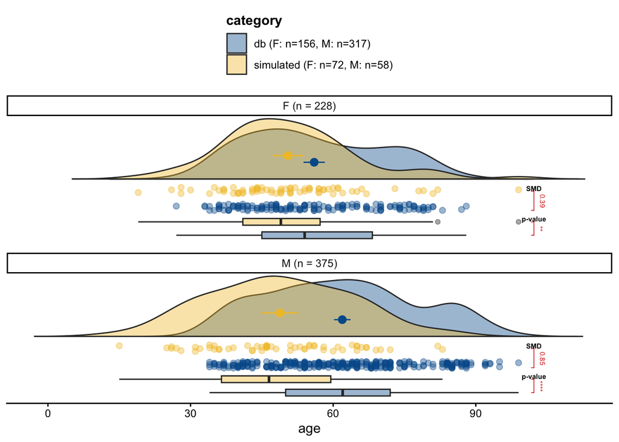

```r
# Concatenate the 2 tables
merged_data <- rbind(metadata_db, simulated_data)

# Use vecmatch visualization function to show the distribution of the 2 groups
raincloud(
  data = merged_data,
  y = age,
  group = category,
  facet=sex,
  significance = "t_test",
  sig_label_color = TRUE
)
```

Groups are heavily unmatched (sex,age). Standardized mean deviation is used as a metric to assess the difference between the 2 distribution and t-test for assessing the difference significance

## Use Vecmatch propensity score matching algoritm, using common support region calculation

```r
results <- run_vecmatch(combined =  merged_data)
```

```
##
## Rectangular CSR Borders Evaluation
## ==================================
##
## Treatment       | Lower CSR limit | Upper CSR limit | Number excluded
## --------------------------------------------------------------------
## simulated       | 0.03501816      | 0.4924819       | 54
## db              | 0.50751807      | 0.9649818       | 54
##
## ===================================================
## The total number of excluded observations is:     54
## Note: You can view the summary of the CSR calculation using the  `attr()` function.[1] "treatment" "simulated" "db"
## Classes 'gps' and 'data.frame':  603 obs. of  3 variables:
##  $ treatment: Factor w/ 2 levels "simulated","db": 2 2 2 2 2 2 2 2 2 2 ...
##  $ simulated: num  0.165 0.238 0.115 0.104 0.177 ...
##  $ db       : num  0.835 0.762 0.885 0.896 0.823 ...
##  - attr(*, "original_data")='data.frame':    603 obs. of  6 variables:
##   ..$ sample_name: chr [1:603] "R14P02_77_FAU0001_ADMCI_NED_A_T_C2" "R14P02_74_FAU0002_ADMCI_NED_A_T_C2" "R19P04_14_MG0213_ADMCI_NED_A_T_C2" "R19P03_78_MG0222_ADMCI_NED_A_T_C2" ...
##   ..$ group_test : chr [1:603] "Controls" "Controls" "Controls" "Controls" ...
##   ..$ sex        : chr [1:603] "F" "F" "M" "M" ...
##   ..$ age        : num [1:603] 83 67 61 63 80 73 65 74 70 62 ...
##   ..$ origin     : chr [1:603] "Netherlands" "Netherlands" "Netherlands" "Netherlands" ...
##   ..$ category   : chr [1:603] "db" "db" "db" "db" ...
##  - attr(*, "function_call")= language estimate_gps(formula = formula, data = combined, method = "vglm", reference = reference)
```

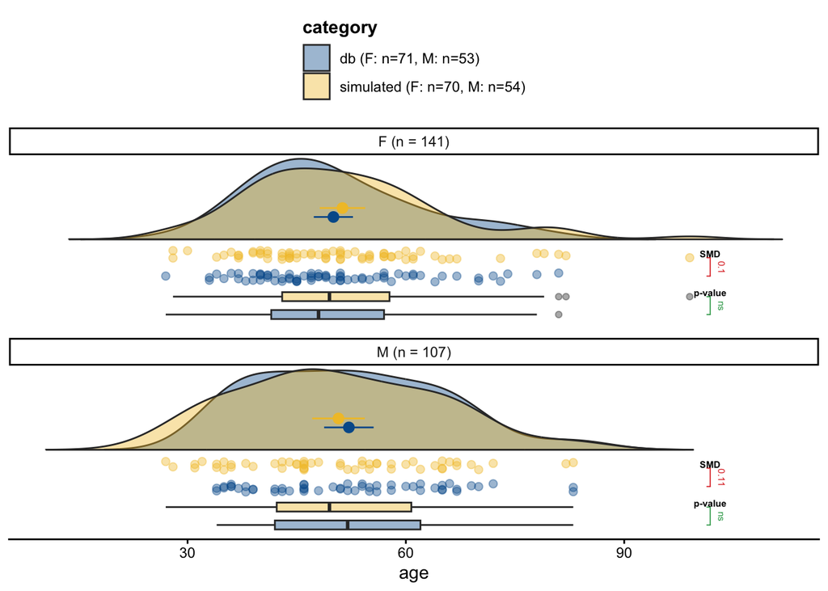

```r
matched_data <- results[[1]]
csr_matrix <- results[[2]]
gps_matrix <- results[[3]]

# Check distributions
raincloud(
  data = matched_data,
  y = age,
  group = category,
  facet=sex,
  significance = "t_test",
  sig_label_color = TRUE
)
```

Groups are now sex-age matched (non-significant difference).

## Remaining Issues

1. **External group cannot be treated as a fixed reference**

   In the current implementation, I could not identify a straightforward way to treat the external group (`simulated_data`) as a fixed reference group. The matching algorithm applies trimming to both groups: not only to the target samples (which may be out-of-distribution), but also to the reference group. This is problematic because the external samples are intended to preserve a distribution representative of the database and ideally should remain unaffected by trimming.
2. **Desirable two-step matching strategy**

   Ideally, I would implement a simplified two-step procedure. First, perform exact 1-to-1 matching within the database (i.e., for each external sample, identify an exact age–sex match in the internal database), thereby avoiding a full `vecmatch` run. Only if at least one exact match cannot be found should the algorithm fall back to generalized propensity score matching using `vecmatch`.